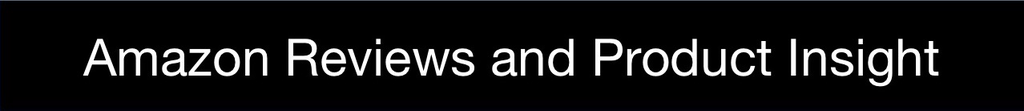

## Introduction

Maintaining a proper marketing strategy involves monitoring consumer reactions to products, and then adjusting to them accordingly. In the brick and mortar space, receipts often come with links to surveys in exchange for product discounts, or other such carrots. Of course surveys are also used within the ecommerce space, however, from a consumer’s standpoint there is far less friction, and the motivation is different. Despite not receiving monetary compensation, online consumers have the knowledge that their responses will be viewed by potential customers. Moreover, they have most likely read reviews themselves, engendering a sense of gratitude that increases survey completion rates, and enhances the quality of the responses.

Retail distribution platforms like Amazon have championed the ecommerce space, and they are an excellent source for customer reviews. Analyzing the reviews offer insight into how customers use a product, and how new users react to it.

In this report I scrape Amazon reviews for a product that I use daily—*Vega All-In-One Plant Based Protein Powder*. The goal is to extract insight about customer perceptions of the product, for such insight can be used to strategize for new and ongoing marketing campaigns. I start by examining the most numerous words and ngrams (multiple word combinations), followed by a sentiment analysis to identify emotional terms.

## Setting Up

The dataframe ‘amz_ratings_text’ is defined with 3 columns and 370 rows, which are empty, but will hold the text that is scrapped from the customer rating pages.

```r
library(rvest); library(dplyr)

url <- 'https://www.amazon.com/Vega-Protein-Powder-Chocolate-Servings/product-reviews/B00R0Y0W8O/ref=cm_cr_getr_d_show_all?ie=UTF8&reviewerType=all_reviews&pageNumber='

amz_ratings_text <- data.frame(Review=character(370),
                               Stars=character(370),
                               Date=character(370),
                               stringsAsFactors=FALSE)
```

## Scrapping Reviews

The reviews were scraped on February 28th, 2018, and at that point there were 366 pages. With 10 reviews per page, it amounted to approximately 3,660 total reviews. The for loop scrapes each of the pages 1-by-1, and the text is then saved into the variable ‘amz_ratings_text’.

```r
for(i in 1:366){

  reviews <- paste(url, as.character(i), sep="")
  webpage <- read_html(reviews)
  amz_ratings_html <- html_nodes(webpage, ".review-text")
  amz_ratings_stars <- html_nodes(webpage, "#cm_cr-review_list  .review-rating")
  amz_ratings_date <- html_nodes(webpage, "#cm_cr-review_list .review-date")

  a <- i*10-9
  b <- i*10

  amz_ratings_text[a:b,1] <- html_text(amz_ratings_html)[1:10]
  amz_ratings_text[a:b,2] <- html_text(amz_ratings_stars)[1:10]
  amz_ratings_text[a:b,3] <- html_text(amz_ratings_date)[1:10]
}
```

Once the for loop is complete, the data are saved and then read in from the csv file. This avoids needing to continually re-scrape the site.

```r
write.csv(amz_ratings_text, "amz_ratings_text.csv", row.names=FALSE)

amz_text <- read.csv("amz_ratings_text_.csv", stringsAsFactors=FALSE)
amz_text <- amz_text[1:3652,]
```

## Identical Comments

It is important to identify reviews that have identical text prior to the analysis. Illegitimate reviews become apparent when the text is scrutinized. Responses like ‘great’, ‘best protein shake’, and other such comments are expected. So when the exact review is left by more than one user, there is no reason to be suspicious. However, when the comments contain more than several words, and they are somewhat unique and appear repeatedly, it suggests that the reviews were copied and pasted by the same user across multiple accounts, making them invalid.

The review ‘Does what it is supposed to do. Highly recommend.’ appears 15 different times. This is either an error, or the same user utilizing multiple accounts. The probability that this exact review was left by 15 unique users is very unlikely. Moreover, the review has a grammatical error, making it seem even less trustworthy. Thus all instances of that review are removed.

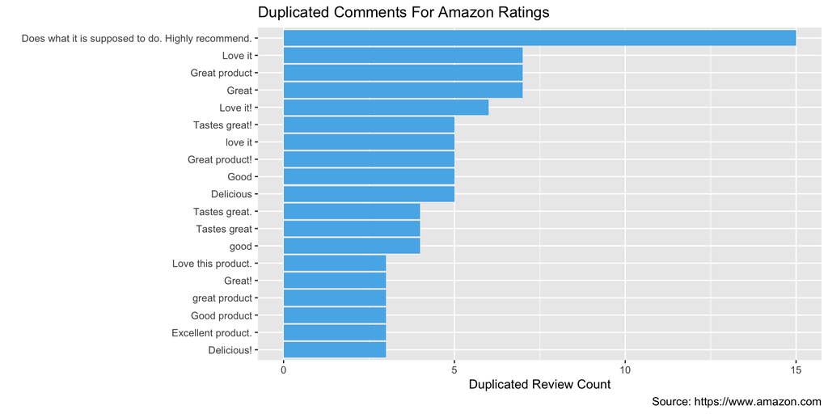

```r
library(ggplot2)

amz_text %>%
  count(Review, sort = TRUE) %>%
  filter(n > 2) %>%
  mutate(Review = reorder(Review, n)) %>%
  ggplot(aes(Review, n)) +
  geom_col(fill="#56B4E9") +
  coord_flip() +
  labs(y = "Duplicated Review Count",
       x = "",
       title = "Duplicated Comments For Amazon Ratings",
       caption="Source: https://www.amazon.com")
```

```r
amz_text_filt <- amz_text %>%
  filter(Review != "Does what it is supposed to do. Highly recommend.")
```

## Punctuation Removal/Formatting Date

Now the reviews can be cleaned and formatted. The values in the ‘Date’ variable had the unnecessary text ‘on’, which was removed, along with the day of the month. Moreover, punctuation marks and digits were excluded, with the exception of apostrophes.

```r
library(lubridate)

amz_text_filt$Date <- gsub("^.*?\\s","",
                           amz_text_filt$Date)

amz_text_filt$Date <- format(mdy(amz_text_filt$Date),
                             format="%m-%y") # Remove day of month.

amz_text_filt$Review_clean <- gsub('\\,|\\.|\\(|\\)|\\!|\\?|\\-|\\~|\\d|"', ' ',
                                   amz_text_filt$Review)
```

## Tokenize Single Words

Before the words can be counted they must be *tokenized*, meaning each word is placed onto a single row. Moreover, common words like ‘it’, ‘the’ and ‘of’, which are referred to as *stop words*, must be excluded.

```r
library(tidytext)
amz_tidy <- amz_text_filt %>%
  unnest_tokens(word, Review_clean) %>%
  anti_join(stop_words)
```

## Word Frequency Count

The most utilized words are primarily descriptor terms about the product, and the other ingredients that are mixed with the powder to create the protein shake.

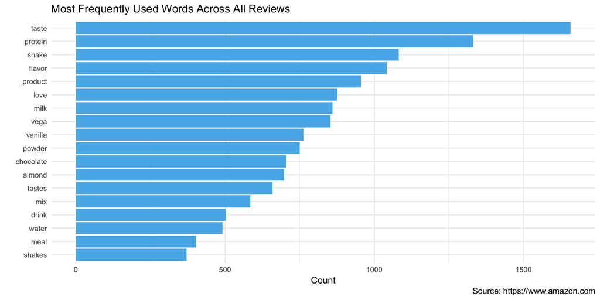

```r
amz_tidy %>%
  count(word, sort=TRUE) %>%
  filter(n >= 370) %>%
  mutate(word = reorder(word, n)) %>%
  ggplot(aes(word, n)) +
  geom_col(fill="#56B4E9") +
  coord_flip() +
  theme_minimal() +
  labs(x = "",
       y = "Count",
       title = "Most Frequently Used Words Across All Reviews",
       caption="Source: https://www.amazon.com")
```

## Bigram Frequency Count

Bigrams are two-word combinations, and like individual words, can be counted to extract insight. The bigrams must be split up and filtered individually for stop words, and after that they are reunited for the frequency analysis.

```r
library(tidyr)
amz_bigrams <- amz_text_filt %>%
  unnest_tokens(bigram, Review, token = "ngrams", n = 2)

bigrams_separated <- amz_bigrams %>%
  separate(bigram, c("word1", "word2"), sep = " ")

bigrams_filtered <- bigrams_separated %>%
  filter(!word1 %in% stop_words$word) %>%
  filter(!word2 %in% stop_words$word)

bigram_counts <- bigrams_filtered %>%
  count(word1, word2, sort = TRUE)

bigrams_united <- bigrams_filtered %>%
  unite(bigram, word1, word2, sep = " ")
```

Like the single word counts, the most popular bigrams are descriptors of the product, with the exception of ‘peanut butter’, which is a common ingredient that is mixed into protein shakes.

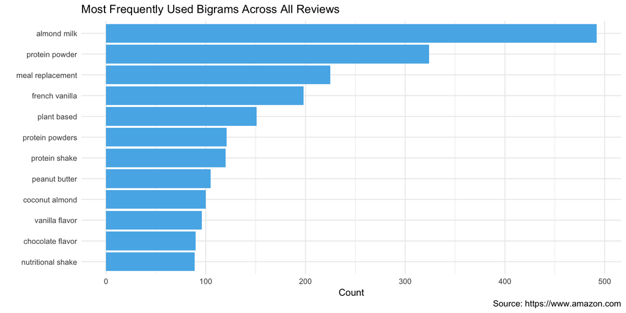

```r
bigrams_united %>%
  count(bigram, sort = TRUE) %>%
  filter(n >= 89) %>%
  mutate(bigram = reorder(bigram, n)) %>%
  ggplot(aes(bigram, n)) +
  geom_col(fill="#56B4E9") +
  coord_flip() +
  theme_minimal() +
  labs(x = "",
       y = "Count",
       title = "Most Frequently Used Bigrams Across All Reviews",
       caption="Source: https://www.amazon.com")
```

An alternative way to assess bigram frequency is to visualize them with nodes and arrows, revealing networks of related bigrams.

```r
library(igraph)
bigram_graph <- bigrams_filtered %>%
  count(word1, word2, sort = TRUE)

colnames(bigram_graph) <- c("Word1", "Word2", "Count")
```

The words ‘almond’, ‘flavor’ and ‘protein’ function as hubs, connecting with multiple words that form high frequency bigrams. Visualizing the bigrams provides a broad snapshot of the general ideas being expressed throughout the reviews.

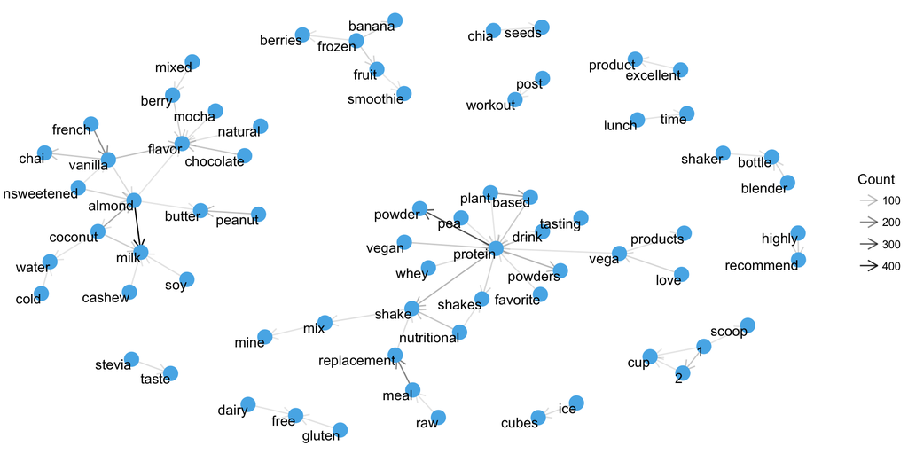

```r
library(ggraph)
a <- grid::arrow(type = "open", length = unit(.12, "inches"))

bigram_graph %>%
  filter(Count > 20) %>%
  graph_from_data_frame() %>%
  ggraph(layout = "fr") +
  geom_edge_link(aes(edge_alpha = Count), show.legend = TRUE,
                 arrow = a, end_cap = circle(.04, 'inches')) +
  geom_node_point(color = "#56B4E9", size = 5) +
  geom_node_text(aes(label = name), vjust = 1, hjust = 1) +
  theme_void()
```

## Sentiment Analysis

Identifying the emotional content within each review offers insight about what customers like about the product, and where they see room for improvement. To this end, 3 different emotion dictionaries are used, all of which use different scales to categorize the affective meaning of words.

#### Finn Årup Nielsen (AFINN)

The AFINN dictionary classifies words as emotional on a scale from -5 to 5, with -5 being the most negative and 5 being the most positive. Overall, there is a fairly strong bias towards positive words. Moreover, when plotted across time, we can see that the positive word bias peaked during the month of March, 2016.

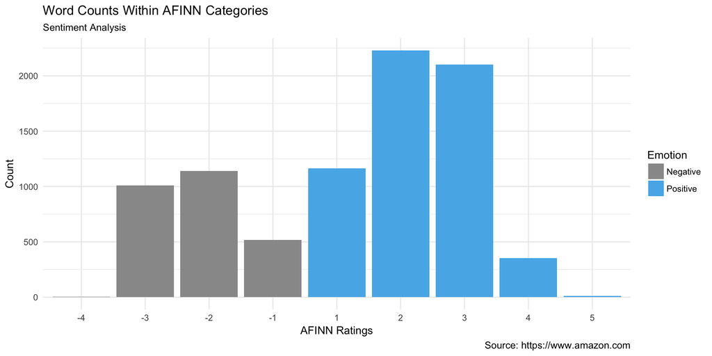

```r
amz_afinn <- amz_tidy %>%
  inner_join(get_sentiments("afinn")) %>%
  count(score) %>%
  mutate(Emo=sign(score))

amz_afinn$Emotion <- ifelse(amz_afinn$Emo == -1, "Negative", "Positive")

amz_afinn %>%
  ggplot(aes(as.factor(score), n, fill=Emotion)) +
  geom_col() +
  scale_fill_manual(values=c("#999999", "#56B4E9")) +
  theme_minimal() +
  theme(legend.position="right") +
  labs(title = "Word Counts Within AFINN Categories",
       subtitle="Sentiment Analysis",
       x = "AFINN Ratings",
       y = "Count",
       caption="Source: https://www.amazon.com")
```

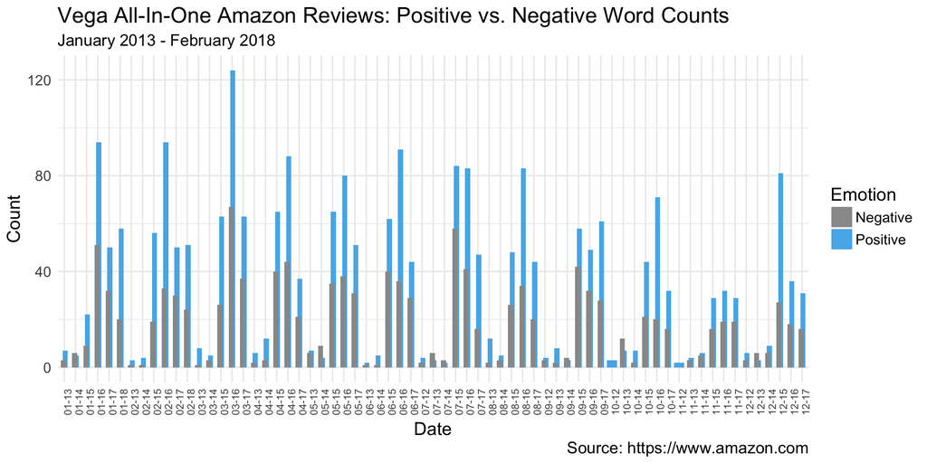

```r
afinn_cnt <- amz_tidy %>%
  inner_join(get_sentiments("afinn")) %>%
  count(score, Date) %>%
  mutate(Emo=sign(score))

afinn_cnt$Emotion <- ifelse(afinn_cnt$Emo == 1, "Positive", "Negative")

 afinn_cnt %>%
   ggplot(aes(x=Date,y=n,fill=as.factor(Emotion))) +
   geom_bar(stat="identity", position = position_dodge(width=0.3)) +
   scale_fill_manual(values=c("#999999", "#56B4E9")) +
   theme_minimal() +
   theme(text = element_text(size=14),
         axis.text.x = element_text(angle = 90, hjust = 1, size = 8)) +
   labs(y="Count",
        x="Date",
        fill = "Emotion",
        title="Vega All-In-One Amazon Reviews: Positive vs. Negative Word Counts",
        subtitle="January 2013 - February 2018",
        caption="Source: https://www.amazon.com")
```

#### Bing

The Bing dictionary groups emotional words into 1 of 2 categories—positive or negative. The most frequent positive words include superlatives like ‘sweet’, ‘healthy’, ‘delicious’ and ‘favorite’, all of which appear over 200 times. As for the negative words, ‘shake’ and ‘frozen’ are by far the most frequently used. However, neither of those words should be considered emotional in this context. Based on the previous analyses, these are popular descriptor terms for how the product is used. Thus, ‘bad’, ‘gritty’ and ‘expensive’ were the most frequently used negative words.

In general, the positive reviews center on the high quality of the product and its high level of nutrition. The negative reviews center on taste and price.

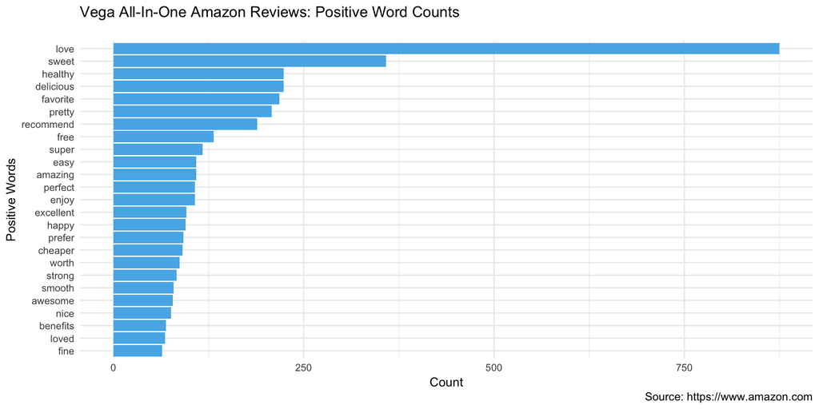

```r
amz_tidy %>%
  inner_join(get_sentiments("bing")) %>%
  filter(sentiment=="positive") %>%
  count(word, sort = TRUE) %>%
  filter(n > 60) %>%
  mutate(word = reorder(word, n)) %>%
  ggplot(aes(word, n)) +
  geom_col(fill="#56B4E9") +
  theme_minimal() +
  coord_flip() +
  labs(y="Count",
        x="Positive Words",
        fill = "",
        title="Vega All-In-One Amazon Reviews: Positive Word Counts",
        subtitle="",
        caption="Source: https://www.amazon.com")
```

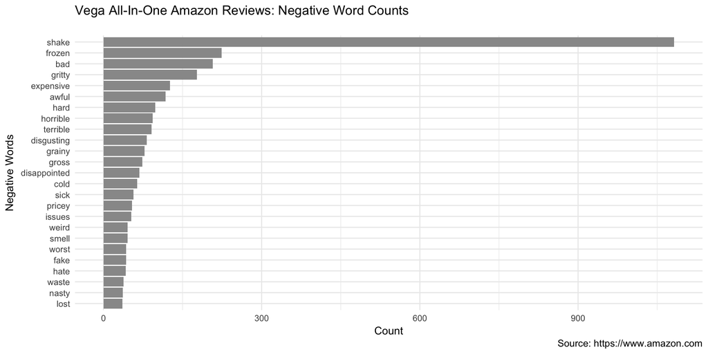

```r
amz_tidy %>%
  inner_join(get_sentiments("bing")) %>%
  filter(sentiment=="negative") %>%
  count(word, sort = TRUE) %>%
  filter(n > 35) %>%
  mutate(word = reorder(word, n)) %>%
  ggplot(aes(word, n)) +
  geom_col(fill="#999999") +
  theme_minimal() +
  coord_flip() +
  labs(y="Count",
        x="Negative Words",
        fill = "",
        title="Vega All-In-One Amazon Reviews: Negative Word Counts",
        subtitle="",
        caption="Source: https://www.amazon.com")
```

#### NRC Word Emotion Association Lexicon (EmoLex)

The NRC library contains 8 ‘basic’ emotion categories. Each word that is related to any of the 8 categories is counted. The positive emotions appear in blue—the negative emotions appear in grey. Joy-related and trust-related words were the most frequently used positive categories, while disgust-related words were the most frequently used negative category. This aligns with the Bing analysis, where the most frequent positive words centered on happiness and trust. Likewise, with the negative words, disgust-related terms were the most frequent, aligning with the Bing analysis where dissatisfaction in the taste of the product was expressed.

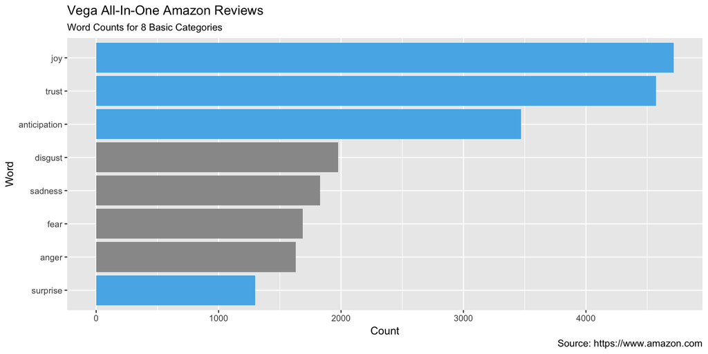

```r
amz_tidy %>%
  inner_join(get_sentiments("nrc")) %>%
  count(sentiment) %>%
  filter(n > 100 & sentiment != "positive" & sentiment != "negative") %>%
  mutate(sentiment = reorder(sentiment, n)) %>%
  ggplot(aes(sentiment, n, fill=sentiment)) +
  geom_col() +
  coord_flip() +
  labs(y="Count", x="Word",
       fill = "",
       title="Vega All-In-One Amazon Reviews",
       subtitle="Word Counts for 8 Basic Categories",
       caption="Source: https://www.amazon.com") +
  scale_fill_manual(values=c("#56B4E9",
                             "#999999",
                             "#999999",
                             "#999999",
                             "#999999",
                             "#56B4E9",
                             "#56B4E9",
                             "#56B4E9"), guide=FALSE)
```

## ‘Not’ Words

Bigrams enable the frequency of ‘not words’ to be calculated, which is critical for contextualizing the sentiment analyses. When measuring the frequency of words such as ‘good’ or ‘bad’, the word may have actually been preceded by a negation, like ‘not’. In such cases the emotional meaning of words can be misinterpreted.

```r
not_words <- bigrams_separated %>%
  filter(word1 == "not" | word1 == "no" | word1 == "never" | word1 == "without") %>%
  inner_join(get_sentiments("afinn"), by = c(word2 = "word")) %>%
  count(word1, word2, score, sort = TRUE) %>%
  ungroup()

not_words$Emotion <- ifelse(not_words$score > 0, "Positive", "Negative")
```

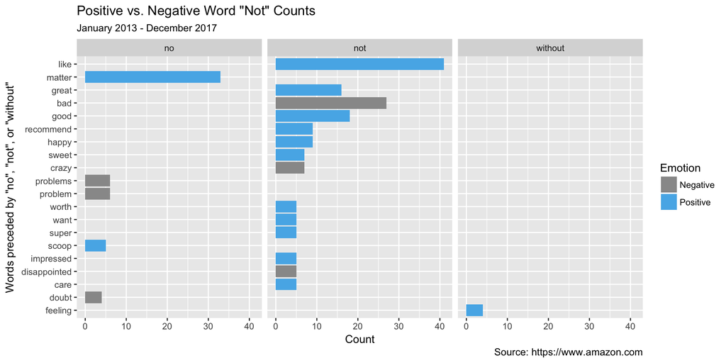

```r
not_words %>%
  mutate(contribution = n) %>%
  arrange(desc(abs(contribution))) %>%
  mutate(word2 = reorder(word2, contribution)) %>%
  head(20) %>%
  ggplot(aes(word2, contribution, fill = Emotion)) +
  geom_col(show.legend = TRUE) +
  facet_wrap(~word1) +
  scale_fill_manual(values=c("#999999", "#56B4E9")) +
  coord_flip() +
  labs(y="Count",
        x="Words preceded by \"no\", \"not\", or \"without\"",
        title="Positive vs. Negative Word \"Not\" Counts",
        subtitle="January 2013 - December 2017",
        caption="Source: https://www.amazon.com")
```

## Summary

The ratings were generally positive, due primarily to the preference for the product’s quality and healthy ingredients. Although the amount of negative words detected within the reviews was low, what was criticized was the taste and the cost of the product. These findings sum up my personal experience with the product quite well.

I first heard of the Vega protein powder back in 2014. It was not widely available back then, and when I eventually tried it, I liked it, but limited my consumption of it due to its high cost. However, since then the cost has reduced considerably, at least in my neck of the woods (Southern California), and I now consume the product daily. I create a shake with it, mixing berries, a banana, real peanut butter and almond milk with it. I skip breakfast and drink coffee in the morning, so when I consume the shake for lunch, I can really feel its effects. The reduction in hunger I that I experience lasts far longer than other plant-based protein powders that I have tried.